# Visualization

## Themes

The `ggplot2` package provides a flexible `theme()` system that allows you to adjust visual aspects of your plots such as fonts, backgrounds, borders, axes, and legend positions. You can use built-in themes or customize your own.

- `theme_bw()` – clean black-and-white
- `theme_minimal()` – light, minimalistic
- `theme_classic()` – traditional axes with no grid
- `theme_void()` – empty canvas, good for maps
- `theme_light()` – lightly gridded version of minimal

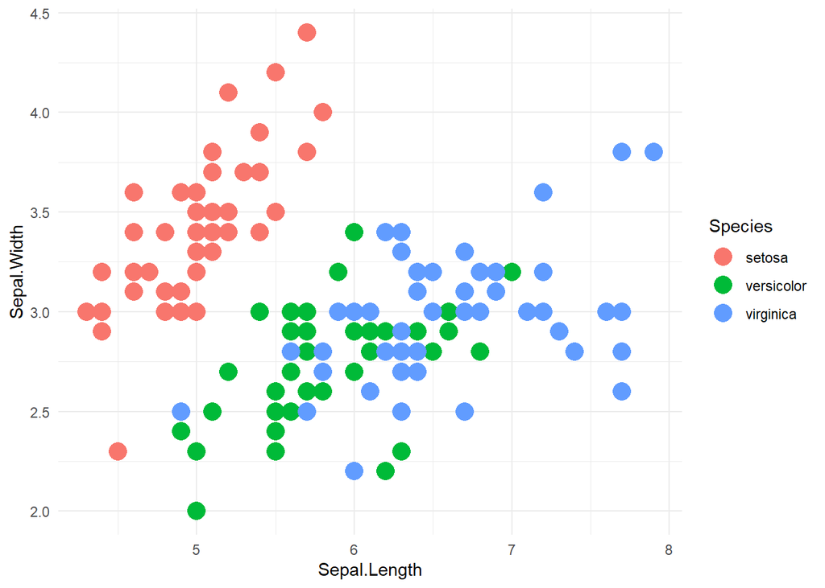

```r
ggplot(iris, aes(x = Sepal.Length, y = Sepal.Width, color = Species)) +
  geom_point(size = 5) +
  theme_minimal()
```

You can tweak the theme with `theme()`:

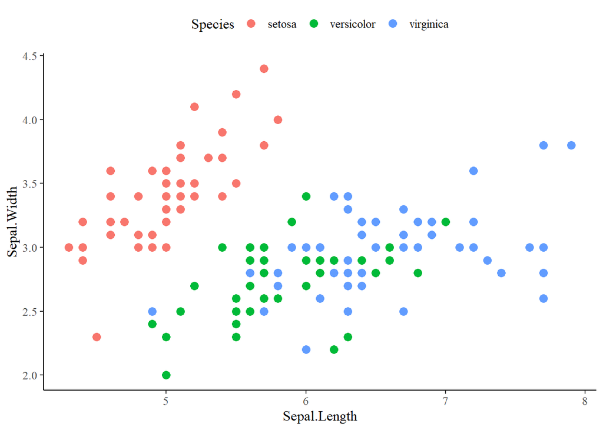

```r
ggplot(iris, aes(Sepal.Length, Sepal.Width, color = Species)) +
  geom_point(size = 3) +
  theme_classic() +
  theme(legend.position = "top",
        text = element_text(family = "serif", size = 12))
```

## Combining multiple geometric layers

You can overlay multiple geometric layers (geoms) in a single plot to combine their strengths. For example, a **violin plot** shows the full distribution, while a **boxplot** shows median, quartiles, and outliers.

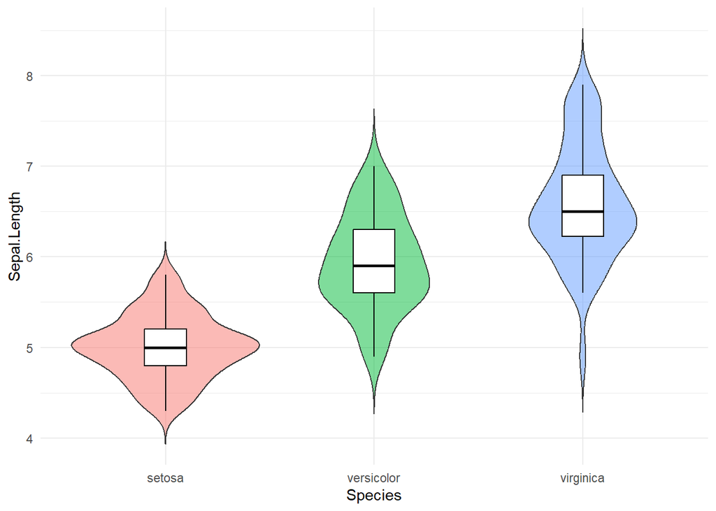

```r
ggplot(iris, aes(x = Species, y = Sepal.Length)) +
  geom_violin(trim = FALSE, alpha = 0.5, aes( fill = Species)) +   # Show full distribution
  geom_boxplot(width = 0.2, color = "black", outlier.shape = NA) +  # Summary stats
  theme_minimal() +
  theme(legend.position = "none")
```

## `ggpubr` for publication-ready plots

The **`ggpubr`** package simplifies the process of making polished, publication-ready figures. It includes easy theming, statistical annotations, and tools for combining plots.

If you do not have the package, you must install it.

```r
install.packages("ggpubr")
```

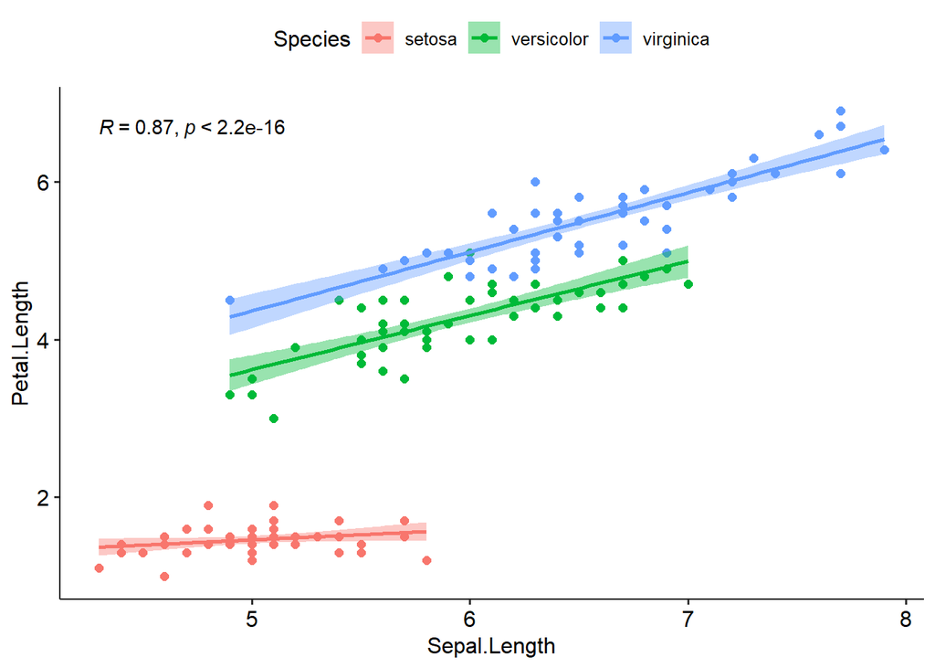

```r
library(ggpubr)

# Scatter plot with stat_cor (correlation)
ggscatter(iris, x = "Sepal.Length",
          y = "Petal.Length",
          color = "Species",
          add = "reg.line",
          conf.int = TRUE,
          cor.coef = TRUE,
          cor.method = "pearson") +
  theme_pubr()
```

The `ggpubr` package makes it easy to create boxplots with **group comparisons**, including **statistical test results** directly annotated on the plot.

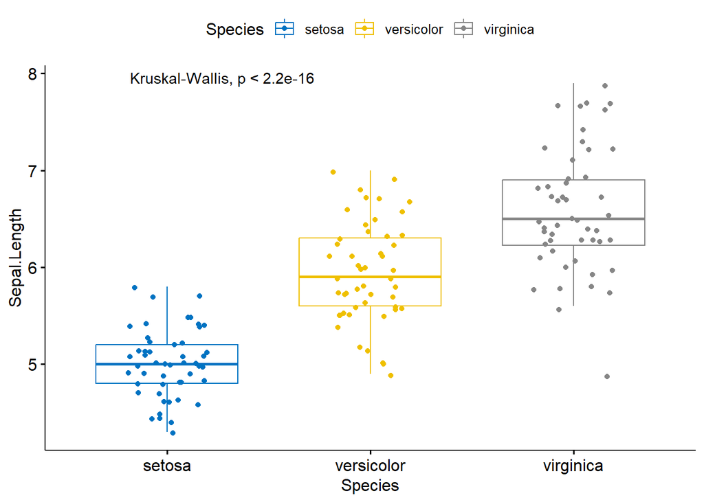

```r
ggboxplot(iris, x = "Species",
          y = "Sepal.Length",
          color = "Species",
          palette = "jco",
          add = "jitter") +
  stat_compare_means()  # Default: Kruskal-Wallis test for >2 groups
```

Add pairwise comparisons (e.g., t-tests between groups)

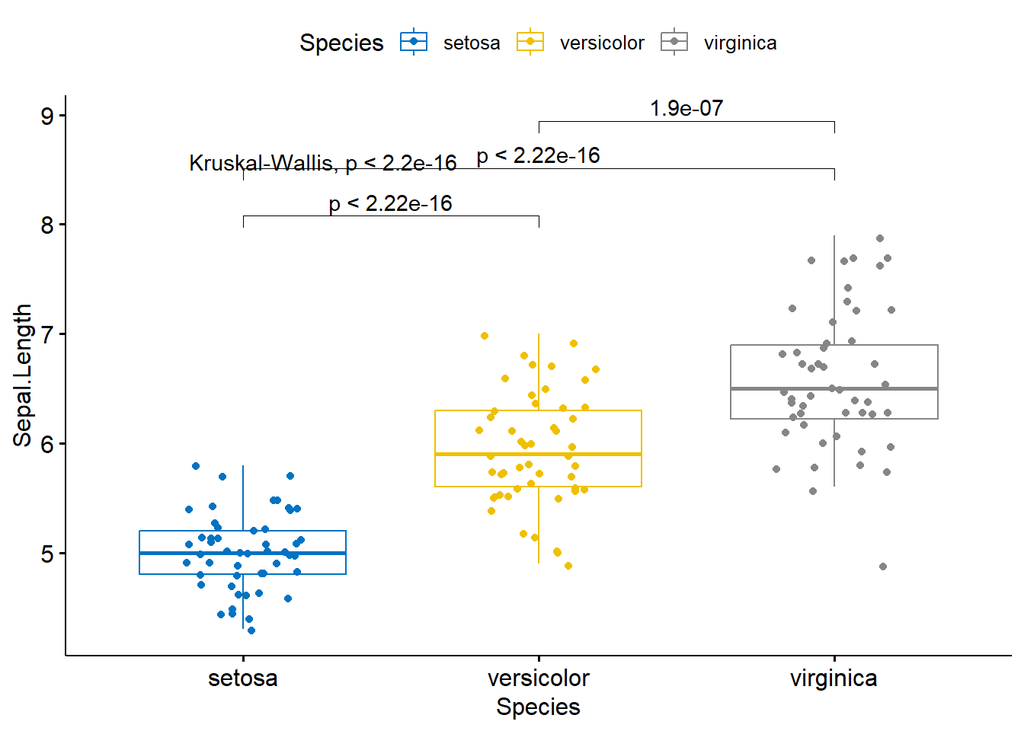

```r
ggboxplot(iris, x = "Species",
          y = "Sepal.Length",
          color = "Species",
          palette = "jco",
          add = "jitter") +
  stat_compare_means(comparisons = list(c("setosa", "versicolor"),
                                        c("setosa", "virginica"),
                                        c("versicolor", "virginica")),
                     method = "t.test") +
  stat_compare_means(label.y = 8.5)  # Global p-value (ANOVA/Kruskal-Wallis)
```

## Reusing and updating a ggplot object with `%+%`

You can store a `ggplot` object in a variable and **reprint or reuse** it later. Using the `%+%` operator, you can update the underlying dataset without changing the plot structure.

This is useful when applying the same plot design to different subsets of data.

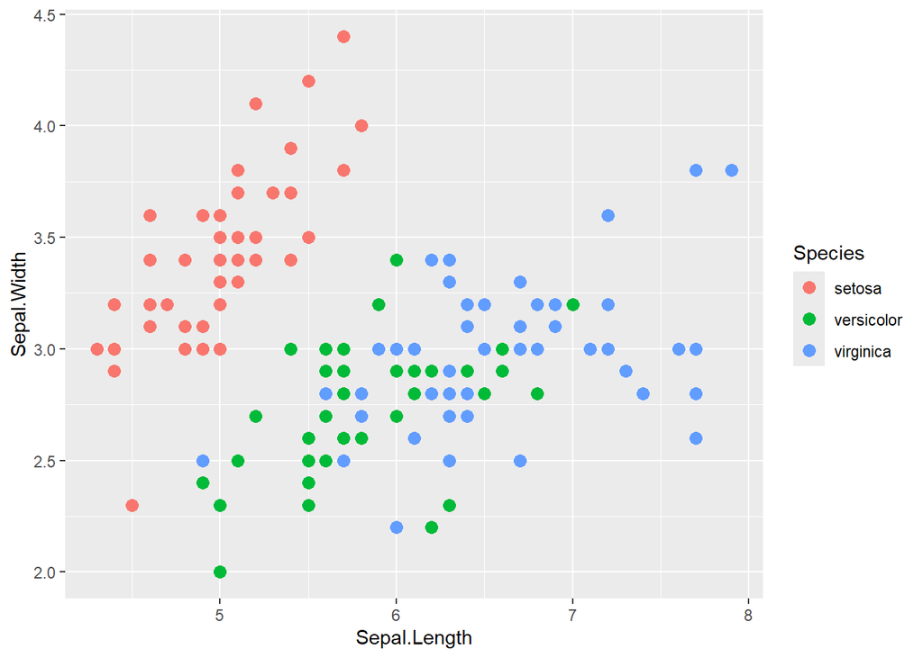

```r
# Create a base plot using the full iris dataset
p <- ggplot(iris, aes(x = Sepal.Length, y = Sepal.Width, color = Species)) +
  geom_point(size = 3)

# Print the original plot
print(p)
```

We now reuse the plot with a **filtered dataset** containing only **`virginica`** species:

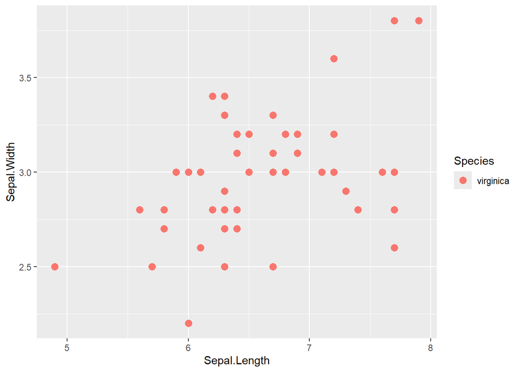

```r
# Replace the data with a subset: only virginica species
p2 <- p %+% iris[iris$Species == "virginica", ]

# Print the updated plot
print(p2)
```

## Combining plots with `cowplot`

The `cowplot` package provides simple and flexible tools for arranging multiple `ggplot2` plots into a single figure. It’s especially useful when preparing figures for publications or presentations.

```r
 install.packages("cowplot")
```

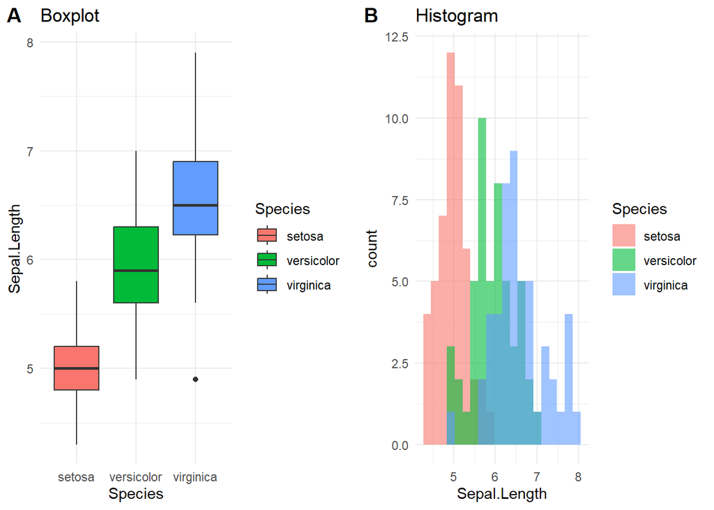

```r
# Create two plots using the iris dataset
p1 <- ggplot(iris, aes(x = Species, y = Sepal.Length, fill = Species)) +
  geom_boxplot() +
  theme_minimal() +
  labs(title = "Boxplot")

p2 <- ggplot(iris, aes(x = Sepal.Length, fill = Species)) +
  geom_histogram(bins = 20, alpha = 0.6, position = "identity") +
  theme_minimal() +
  labs(title = "Histogram")

# Combine side by side
cowplot::plot_grid(p1, p2, labels = c("A", "B"))
```

| Argument | Description | Example |
| --- | --- | --- |
| `...` | The plots to combine | `plot_grid(p1, p2)` |
| `ncol` | Number of columns | `ncol = 2` |
| `nrow` | Number of rows | `nrow = 1` |
| `labels` | Add labels to subplots (e.g., “A”, “B”, …) | `labels = c("A", "B")` |
| `label_size` | Size of subplot labels | `label_size = 14` |
| `align` | Align plots by axis (`"h"`, `"v"`, `"hv"`) | `align = "hv"` |
| `axis` | Share axis text/limits (`"t"`, `"b"`, `"l"`, `"r"`) | `axis = "tb"` |
| `rel_widths` | Relative widths of columns | `rel_widths = c(1, 2)` |
| `rel_heights` | Relative heights of rows | `rel_heights = c(1, 1.5)` |

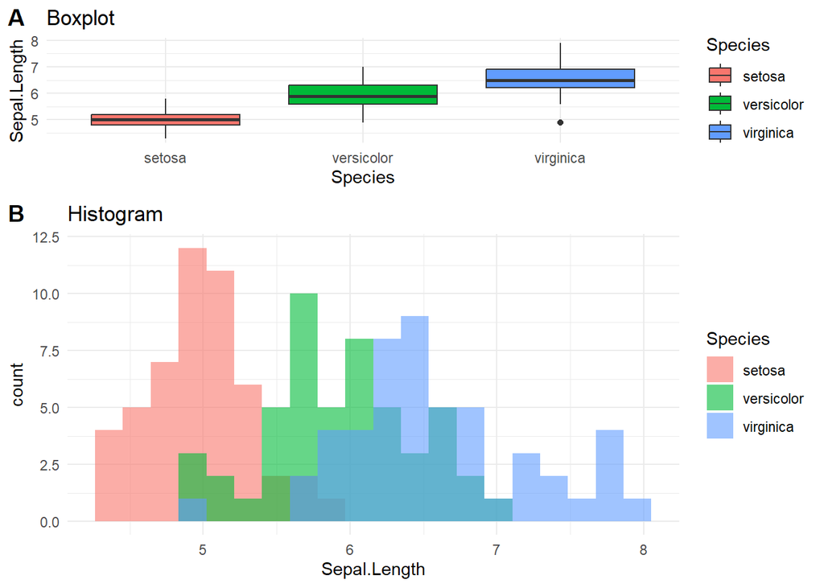

```r
cowplot::plot_grid(p1, p2, ncol = 1, rel_heights = c(1, 2), labels = c("A", "B"))
```

## Saving a Plot with `ggsave()`

You can save any `ggplot` object to a file using the `ggsave()` function.

| Argument | Description | Example |
| --- | --- | --- |
| `filename` | Output file name (with extension) | `"plot.pdf"`, `"plot.png"` |
| `plot` | Plot object to save (optional) | `plot = p` |
| `width` | Width in inches | `width = 6` |
| `height` | Height in inches | `height = 4` |
| `dpi` | Resolution (use 300 for print) | `dpi = 300` |

```r
ggsave("results/scatterplot.png", # be careful about the path
       plot = p1,
       width = 6,
       height = 4,
       dpi = 300)
```

**Tip**

For more information and help with making graphs see the [R Graphics Cookbook](https://r-graphics.org/)